# Refractory anaphylaxis: Data from the European Anaphylaxis Registry

Wojciech Francuzik

Sabine Dölle-Bierke

Franziska Ruëff

Margitta Worm

11 Juli, 2018

*Department of Dermatology, Venerology and Allergology, Charité – Universitätsmedizin Berlin, corporate member of Freie Universität Berlin, Humboldt-Universität zu Berlin, and Berlin Institute of Health, Charitéplatz 1, 10117 Berlin,

**Klinik und Poliklinik für Dermatologie und Allergologie, Frauenlobstraße 9–11, 80337 München

**Corresponding author:** Prof. Dr. med. M. Worm margitta.worm@charite.de Phone: +49 30 450 529 005; Fax: +49 30 450 529 902

**Keywords:** anaphylaxis, adrenaline (epinephrine), betablockers, Insect venom allergy, Drug allergic reactions

# 1 Abstract

Refractory anaphylaxis (unresponsive to treatment with at least 2 doses of minimum 300 mg adrenaline) is a rare and often fatal hypersensitivity reaction. Based on this, its definition, prevalence, and risk factors are only vaguely described.  
Using the data from the European Anaphylaxis Registry (11596 cases in total) we were able to identify cases of refractory anaphylaxis (n = 42) and to analyse these in comparison to a control group of severe anaphylaxis cases (n = 4820). The data show that drugs more frequently elicited refractory anaphylaxis (50% of cases, p < 0.0001) than in other severe anaphylaxis cases (18.4%). Cases elicited by insects (n = 8) were more often due to bees in refractory cases (62.5% vs 19.4%, p = 0.00921). The refractory cases occurred more frequently in a perioperative setting E(45.2% vs. 9.05, p < 0.0001). Intramuscular adrenaline (as a first line therapy) was administered in 17.5% of refractory cases, whereas in 87.5% of cases was given intravenously (significantly more often than in severe anaphylaxis cases: 14.1%, p < 0.0001). Second line treatment options (e.g. vasopression with dopamine, methylene blue, glucagon) were not used at all in the treatment of refractory cases. The mortality rate in refractory anaphylaxis was significantly higher (26.2%) than in severe cases (0.353%, p < 0.0001). Although multiple guidelines on anaphylaxis have been published, the clinical adherence to these standards can be improved. The low use of intramuscular adrenaline as a first line therapy might contribute to refractoriness of an episode. Also, the lack of suggested second line medication use in refractory cases indicate that the availability of these drug is restricted or anaphylaxis management guidelines may need a revision in order to provide clear algorithms for severe refractory anaphylaxis.

# 2 Introduction

Anaphylaxis is a non-homogeneous clinical diagnosis, depending on varoius triggering, and augmenting factors. This variability introduces a wide range of possible reaction-symptom severity. Therefore multiple subtypes of anaphylaxis have been previously identified (i.e. food dependent exercise induced anaphylaxis, venom anaphylaxis, biphasic anapylaxis).

The mainstay of anaphylaxis management is the intramuscular dose of adrenaline, but in the most severe cases of anaphylaxis it might be insufficient to restore a stable patient status. Refractory anaphylaxis (although the established definition is lacking) might be defined as anaphylaxis meeting the criteria by NIAID/FAAN [Sampson2006] which, after the treatment with at least 2 doses of minimum 300 mg adrenaline, does not result in an expected normalization of clinical symptoms. Typical elicitors and symptoms of refractory anaphylaxis, as well as the theraputic strategy for the most severe cases differ from the usual reactions and call for a specific research and targeted guideline development for refractory anaphylaxis cases.

We aimed to distinguish the prevalence of refractory anaphylaxis among anaphylaxis cases and to describe its symptoms and factors which may increase the risk of a refractory anaphylaxis episode.

# 3 Methods

The European Anaphylaxis Registry (described in detail elsewhere [Grabenhenrich2016]) provided data for this analysis status from May 2018. Based on an electronic questionnaire (avaliable at www.anaphylaxie.net), we selected cases where patients received at least two doses of adrenaline, and failed to recover adequately and assigned them to the “refractory anaphylaxis group”. The flowchart in figure 8.1 represents the detailed cases selection process.

The final database consisted of 42 cases of refractory anaphylaxis from 7 countries: Germany: 19, Austria: 2, Switzerland: 11, Poland: 2, Spain: 1, France: 6, Ireland: 1. We compared these to a group of severe, non-refractory cases of anaphylaxis. Severe reactions were identified based on the definition of by NIAID/FAAN [Sampson2006] and presented with significant hypoxia, cyanosis, hypotension (SBP < 90 mm Hg in adults), confusion, collapse, loss of conciusness, or incontinence. We compared the frequency of various elicitors, symptoms, and factors known to incease the risk of severe anphylaxis Cofactors in both groups. We also compared how the cases were managed.

The statistical analysis was performed in the R Statistical Package [R]. Simple comparison of nominal variables was performed using Fischer’s exact test, continous variables were analysed using Mann-Whithney U test. We defined statistical significance as α = 0.05.

# 4 Results

The European Anaphylaxis Registry contained 42 cases of refractory anaphylaxis (reported in years 2007-2017) and in 4820 cases severe, non-refractory anaphlaxis was diagnosed. The frequency of refractory anaphylaxis was therefore 0.37% of all anaphylaxis cases reported in the registry from european countries in years 2007 - 2017. It may be stated that each year 0.853% $\pm$ 0.765% of severe anaphylactic episodes are refractory to treatment with adrenaline. Moreover, if we consider patients undergoing a medical procedure (who undergo anaphylaxis in a peroperative setting), nearly 3.72% (4.36 times more) patients present with reactions that do not respond to adrenaline.

The percentage of males within the refratory anaphylaxis group was 47.6% and the mean age at the reaction was 41.4 ± 20.8 years, which did not differ from severe, non-refractory cases, p = 0.897). There were however significantly more cases of concomitant malignant diseases in the refractory anaphylaxis group. Patients with refractory reactions more frequently had a previous anaphylactic reaction in their medical history (p = 0.0336). The demographic summary of refractory cases can be found in table 9.1

The most common drugs eliciting anaphylaxis refractory to adrenaline were antibiotics and X-ray contrast medium. Insect-venom-elicited, refractory cases were significantly more often elicited by bee-stings than severe, non-refractory cases, whereas the yellow-jacket-stings were most common in non-refractory anaphylaxis cases (table 9.3).

## 4.2 Therapy

In 77.5% of refractory cases, the second dose of adrenaline was given by a professional (significantly more than in non-refractory cases 9.08%, p < 0.0001).

Corticosteroids iv. were the second most frequently administered group of drugs in refractory cases (as a first and second line treatment), outpacing antihistaminic drugs and volume replacement therapy, and were significantly more often given in refractory cases. Volume replacement therapy was given initially in 65% of refractory cases but was sustained only in 27.6% as the therapy progressed in the hospital environment.

Second line medication like dopamine, glucagon and methylene blue were neglected in all refractory anaphylaxis cases as well as in severe non-refractory ones, however patients with refractory anaphylaxis were more frequently admitted to the hospital and treated at the ICUs. Table 9.5 illustrated the therapy of refractory anaphylaxis cases.

## 4.3 Death

Fatal reactions occured after 30 minutes to 120 minutes - when the CPR was unsuccessfull. In cases where patients respondend to life support procedures, but failed to be reanimated due to post-resuscitation squelae (e.g. hypoxic brain injury), death occured in the next 3-8 days.

## 4.4 Cofactors

Patients with refractory anaphylaxis more often had concomitant asthma and malignant diseases in the past. Also other unspecified concomitant conditions were significantly more often reported in refractory cases (although they were not explicitly stated in the quesstionnaire). It is worth noticing that concomitant cardiologic conditions, diabetes and mastocytosis were similarily frequent in both groups.

Patients with refractory anaphylaxis more often used proton pump inhibitors and acetylsalicilic acid than patients with severe non-refractory anaphylaxis. Other (non-disclosed) medications were also more frequent in refractory cases.

The intensity of of physical exercise exceeding the reaction was indifferent between groups, however the psychological burden was reported 3 times more frequently in refractory cases (see table 9.6).

# 5 Discussion

## 5.1 Key results

### 5.1.2 Elicitors

Although drugs were the most commonly occuring elicitor, there were also more refractory cases elicited by bees. Plausible explanations for this observation, might include either longer exposition to the allergen (longer stings predispose to deeper deposition of the venom and slower metabolizing) or more efficient vasodilatation due to biochemical differences between wasp and bee venom. [insekt sting anaphylaxis, Golden, 2007]. In such case - patients might benefit from vasopressive medication.

Antibiotics, although commonly trigerring type IV hypersensitivity reactions, are rarely reported in the literature as the cause of a refractory anaphylaxis. Radio-contrast media (RCM) are however common in eliciting hypersensitivity episodes refractory to adrenaline.

### 5.1.3 Cofactors

After performing a thorough analysis of cofactors associated with an increased risk of severe anaphylaxis we saw that concomitant asthma rather had a protective effect. This association is probably non-linear as the present analysis indicated concomitant asthma as a risk factor for a refractory episode. The reason for this is unclear. Either patients recive already antihistaminic and mast cell blocking agents and their reactionto adrenaline is therefrore restricted, or the episode elicits a bronchospasm that is refractory to adrenaline and therfore results in a prolonged anaphylactic episode. This would also clarify why we saw more respiratory distress symptoms in the refractory anaphylaxis cases.

### 5.1.4 adrenaline use inconsistent and too low

After revising the therapeutic procedures we saw significantly more adrenalin use in the refractory cases, but it could be used even more extensively in these life-threathening reactions. This observation might indicate that in fact the emergency teams are using these life-saving measures too cautiously due to possible side effects. Methylene blue and vasopressors have been described to successfully restore refractory hypotension, but their actual use in anaphylaxis patients is scarce, although they are mentioned in recognized guidelens on the management of anaphylaxis.

### 5.1.5 Cofactors

Although we have previously identified age and male sex to be associated with more severe anaphylaxis, these factors seem to be less important when refractory anaphylaxis is considered. Asthma and malignant diseases in the medical history were more frequent in the refractory anaphylaxis group and the reason for this is unclear. It is however interesting that past malignant diseases were mostly recognized in male refractory anaphylaxis patients.

We have previously proven the role of acetysalicylic acid in increasing the risk of severe anaphylaxis. The role of proton pump inhibitors however has not been identified as a cofactor, and there are only reports on ppi as elicitors of anaphylaxis.

## 5.2 Limitations

Low number of refractory cases Definition is not uniform and hard to state based on the questions in our registry Per definition if fatal reaction occurs before the second dose of adrenaline it cannot be diagnosed as refractory although it as well could be refractory.

## 5.3 Conclusion

We aimed to distinguish the frequency and clinical features of refractory anaphylaxis in order to revise the current managment of this life-threatening condition.

# 6 Acknowledgements

# 7 References

# 8 Figures

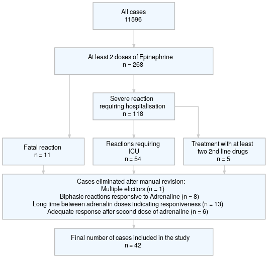

Figure 8.1: Flowchart illustrating the cases selection process for the final database.

# 9 Tables

Table 9.1: Summary of the refractory anaphylaxis cases. Age is represented by a mean value, other as fractions [%]

|  | Group | n | Age | Cardiologic | DM | Food allergy | Mastocytosis | Malignancy | Atopic dermatitis |
| --- | --- | --- | --- | --- | --- | --- | --- | --- | --- |
| female | refractory | 22 | 40 | 31.8 | 9.09 | 13.6 | 9.09 | 0 | 18.2 |
| male | refractory | 20 | 43 | 30 | 15 | 5 | 5 | 15 | 5 |
| female | severe | 2421 | 43.4 | 20.6 | 2.27 | 5.37 | 2.56 | 2.19 | 6.73 |
| male | severe | 2399 | 40.2 | 22.9 | 3.58 | 5.84 | 2.54 | 2.08 | 6.25 |
|  | p value | 0.781 | 0.897 | 0.191 | 0.0701 | 1 | 0.0993 | 0.0663 | 0.2 |

Table 9.2: Summary of elicitors in the refractory anaphylaxis cases and severe anaphylaxis cases as a control.

|  | n | refractory ANA [%] | severe ANA [%] | p value | Age | Male sex [%] | Perioperative [%] | Food allergy [%] |
| --- | --- | --- | --- | --- | --- | --- | --- | --- |
| food | 9 | 21.4 | 33.5 | 0.856 | 17.4 | 55.6 | 0 | 33.3 |
| drugs | 21 | 50 | 18.4 | 1.2e-05 | 48.8 | 42.9 | 90.5 | 0 |
| insects | 8 | 19 | 38.7 | 0.00014 | 46.5 | 62.5 | 0 | 0 |
| other | 2 | 4.76 | 3.38 | 0.361 | 38 | 0 | 0 | 50 |
| unkown | 2 | 4.76 | 6.02 | 1.2e-05 | 55.5 | 50 | 0 | 0 |

Table 9.3: Summary of elicitors in the refractory anaphylaxis cases and severe anaphylaxis cases as a control.

| Elicitor | severe ANA [%] | refractory ANA [%] | p value |
| --- | --- | --- | --- |
| antibiotics | 30.8 | 38.1 | 0.479 |
| xray_cm | 4.78 | 14.3 | 0.0823 |
| legumes | 16.6 | 33.3 | 0.178 |
| bee | 19.4 | 62.5 | 0.00921 |
| yellow jacket | 69.3 | 25 | 0.013 |

p-value derived from the Fisher exact test.

| Symptom | severe ANA [%] | refractory ANA [%] | p value |
| --- | --- | --- | --- |
| q_111_pruritus | 45.4 | 23.8 | 0.00487 |
| q_112 | 44.8 | 26.2 | 0.0186 |
| q_113 | 62.1 | 81 | 0.0154 |
| q_113_respiratory_arrest | 3.03 | 28.6 | 4.36e-09 |
| q_113_chest_tightness_v5 | 12 | 2.38 | 0.0543 |
| q_113_throat_tightness_v5 | 19.2 | 7.14 | 0.0479 |
| q_113_wheezing_expiratory_distress_v5 | 6.86 | 26.2 | 0.000108 |
| q_113_stridor_inspiratory | 5.31 | 19 | 0.0016 |
| q_114_loss_of_consciousness | 37.4 | 40.5 | 0.749 |
| q_114_palpitations_cardiac_arrythmia_v5 | 4.45 | 11.9 | 0.0397 |
| q_114_cardiac_arrest | 3.07 | 42.9 | 2.76e-16 |
| q_114_dizziness | 38.7 | 14.3 | 0.000733 |
| q_140_fatal | 0.353 | 26.2 | 9.36e-17 |

Table 9.5: Summary of therapeutic measures in the refractory anaphylaxis cases and severe anaphylaxis cases as a control. 2nd line therapy was performed after the initial rescue agent called for help. It usually was a professional medical emergeny team.

| Therapy | severe ANA [%] | refractory ANA [%] | p value |
| --- | --- | --- | --- |
| q_522_adren_im | 9.59 | 17.5 | 0.102 |
| q_522_adren_iv | 14.1 | 87.5 | 1.25e-24 |
| q_552_adren_iv_v5 | 3.23 | 58.6 | 5.21e-17 |
| q_522_volume | 23.5 | 65 | 3.43e-08 |
| q_552_volume_v5 | 14.9 | 27.6 | 0.0678 |
| q_522_antih_iv | 46.8 | 67.5 | 0.0105 |
| q_552_antih_iv_v5 | 17.1 | 31 | 0.077 |
| q_521_cortic_v5 | 33 | 37.5 | 0.724 |
| q_522_cortico_iv | 55.8 | 77.5 | 0.00607 |
| q_552_cortico_iv_v5 | 23.9 | 41.4 | 0.0456 |
| q_522_beta2_iv | 0.76 | 2.5 | 0.269 |
| q_552_beta2_inhal_v5 | 3.32 | 10.3 | 0.0776 |
| q_522_theo_iv | 0.475 | 0 | 1 |
| q_522_o2 | 10.8 | 50 | 9.82e-10 |
| q_552_dopamine_v5 | 0.185 | 0 | 1 |
| q_552_glucagon_v5 | 0.0923 | 0 | 1 |
| q_552_methyleneb_v5 | 0 | 0 | 1 |
| q_561_hospital_admission_v6 | 52.2 | 92.3 | 1.14e-07 |
| q_562_intensive_care_v6 | 14.1 | 84.6 | 3.72e-22 |

Table 9.6: Factors potentially increasing the risk of a severe anaphylaxis

| Factor | severe ANA [%] | refractory ANA [%] | p value |
| --- | --- | --- | --- |
| q_410_cur | 61.1 | 83.3 | 0.00238 |
| q_410_asthma_cur | 11.5 | 28.6 | 0.00233 |
| q_410_ad_cur | 6.5 | 11.9 | 0.194 |
| q_410_diab_cur_v6 | 5.45 | 13.2 | 0.0565 |
| q_410_cardio_cur | 21.7 | 31 | 0.186 |
| q_410_infect_cur | 3.2 | 4.76 | 0.393 |
| q_410_malig_prev_v5 | 2.8 | 9.52 | 0.0314 |
| q_410_masto_cur | 2.55 | 7.14 | 0.0941 |
| q_410_other_cur | 14.9 | 35.7 | 0.000752 |
| q_4211_exercise | 25.2 | 21.4 | 0.721 |
| q_422_stress | 6.79 | 26.2 | 9.43e-05 |
| q_423 | 35.9 | 54.8 | 0.0148 |
| q_423_asa | 5.87 | 16.7 | 0.0111 |
| q_423_beta | 9.96 | 14.3 | 0.306 |
| q_423_ppi_v6 | 5.45 | 18.4 | 0.00454 |
| q_423_other | 17.4 | 40.5 | 0.00068 |
| q_425_alcohol | 4.67 | 2.38 | 0.722 |

p-value derived from the Fisher exact test.